# Titanic Dataset: Analysis Framework for High-Level Research Questions

## Step 5: Visualization of Missing Data Patterns

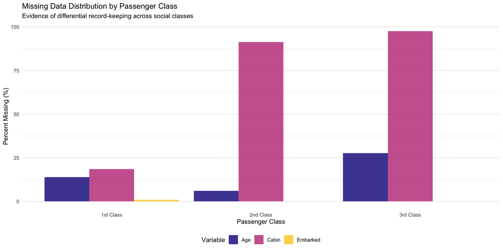

```r
# Prepare data for visualization
missing_by_class_long <- titanic_rq3 %>%
  mutate(
    Pclass = factor(Pclass, labels = c("1st Class", "2nd Class", "3rd Class"))
  ) %>%
  group_by(Pclass) %>%
  summarise(
    Cabin = round(100 * mean(missing_cabin), 1),
    Age = round(100 * mean(missing_age), 1),
    Embarked = round(100 * mean(missing_embarked), 1),
    .groups = "drop"
  ) %>%
  pivot_longer(cols = -Pclass, names_to = "Variable", values_to = "pct_missing")

# Plot: Missing data by class
p1 <- ggplot(missing_by_class_long, aes(x = Pclass, y = pct_missing, fill = Variable)) +
  geom_col(position = "dodge", alpha = 0.8) +
  scale_fill_viridis_d(option = "plasma", end = 0.9) +
  theme_minimal() +
  theme(legend.position = "bottom", panel.grid.major.x = element_blank()) +
  labs(
    title = "Missing Data Distribution by Passenger Class",
    subtitle = "Evidence of differential record-keeping across social classes",
    x = "Passenger Class",
    y = "Percent Missing (%)"
  )

# Plot 2: Survival stratified by cabin presence and class
survival_data <- titanic_rq3 %>%
  mutate(
    Pclass = factor(Pclass, labels = c("1st Class", "2nd Class", "3rd Class")),
    cabin_status = factor(
      if_else(missing_cabin, "No Cabin Data", "Has Cabin Data"),
      levels = c("No Cabin Data", "Has Cabin Data")
    )
  ) %>%
  group_by(Pclass, cabin_status) %>%
  summarise(
    survival_rate = mean(Survived, na.rm = TRUE),
    n = n(),
    .groups = "drop"
  )

p2 <- ggplot(survival_data, aes(x = Pclass, y = survival_rate, fill = cabin_status)) +
  geom_col(position = "dodge", alpha = 0.8) +
  scale_y_continuous(labels = scales::percent) +
  scale_fill_viridis_d(option = "magma", end = 0.8, direction = -1) +
  theme_minimal() +
  theme(legend.position = "bottom", panel.grid.major.x = element_blank()) +
  labs(
    title = "Survival by Class and Cabin Data Presence",
    subtitle = "Does record-keeping quality correlate with survival outcomes?",
    x = "Passenger Class",
    y = "Survival Rate",
    fill = "Record Status"
  )

p1
```

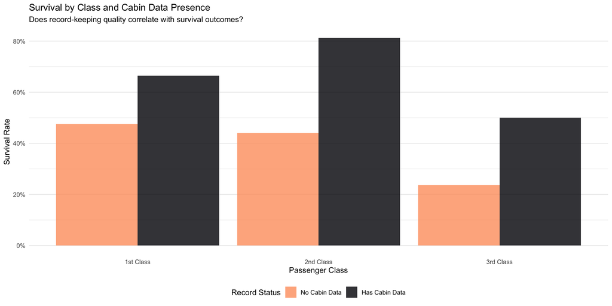

```r
p2
```

# Integration: How These Questions Connect

```r
# Create a summary table connecting findings across research questions
integration_summary <- tibble(
  `Research Question` = c(
    "RQ1: Class Effect Mediation",
    "RQ2: Rule Application Consistency",
    "RQ3: Missing Data as Inequality Signal"
  ),
  `Key Operationalization` = c(
    "Mediation analysis: Total vs. direct effect of class, via access proxies (fare, cabin)",
    "Interaction models: Sex × Class, Sex × Context; test if WCF rule is uniform",
    "Missingness patterns: Is missing cabin/age systematic? Related to survival?"
  ),
  `Critical Finding to Look For` = c(
    "Does access proxy (fare, cabin) explain most or little of class-survival gap?",
    "Do gender/age advantages differ across classes or travel contexts?",
    "Is missing data concentrated in lower classes? Correlated with survival?"
  ),
  `Interpretation Theme` = c(
    "Mechanism: access vs. priority-based",
    "Context dependency: do norms apply uniformly or adapt to constraints?",
    "Equity: does record-keeping reflect underlying social structure?"
  )
)

integration_summary %>%
  kable(
    col.names = c("Research Question", "Operationalization", "Key Finding", "Theme"),
    caption = "Integration: How the three research questions connect analytically"
  )
```

Integration: How the three research questions connect analytically

| Research Question | Operationalization | Key Finding | Theme |
| --- | --- | --- | --- |
| RQ1: Class Effect Mediation | Mediation analysis: Total vs. direct effect of class, via access proxies (fare, cabin) | Does access proxy (fare, cabin) explain most or little of class-survival gap? | Mechanism: access vs. priority-based |
| RQ2: Rule Application Consistency | Interaction models: Sex × Class, Sex × Context; test if WCF rule is uniform | Do gender/age advantages differ across classes or travel contexts? | Context dependency: do norms apply uniformly or adapt to constraints? |
| RQ3: Missing Data as Inequality Signal | Missingness patterns: Is missing cabin/age systematic? Related to survival? | Is missing data concentrated in lower classes? Correlated with survival? | Equity: does record-keeping reflect underlying social structure? |

```r
cat("\n\nThese three research questions form an integrated analytical narrative:\n")
```

```
These three research questions form an integrated analytical narrative:
```

```r
cat("1. Class mattered for survival, but WHY? (mediation)\n")
```

```
1. Class mattered for survival, but WHY? (mediation)
```

```r
cat("2. Did stated rules apply uniformly, or did context modify them? (interaction)\n")
```

```
2. Did stated rules apply uniformly, or did context modify them? (interaction)
```

```r
cat("3. Can we trust our data, or does missingness bias conclusions? (sensitivity)\n\n")
```

```
3. Can we trust our data, or does missingness bias conclusions? (sensitivity)
```

```r
cat("Together, they move beyond descriptive findings to causal and methodological insights.\n")
```

```
Together, they move beyond descriptive findings to causal and methodological insights.
```

The three research questions are designed to work together: understanding *mechanisms* (RQ1), *context-dependency* (RQ2), and *data quality* (RQ3) creates a more complete picture of the Titanic disaster than any single analysis could provide.

# Conclusion: Design vs. Discovery

This report emphasizes **analytical design** over direct conclusions. Rather than stating “class caused survival inequality,” it outlines the conceptual and statistical steps needed to support such a claim. Key principles applied throughout:

1. **Explicit operationalization**: Abstract concepts (access, visibility, context) are translated into measurable variables.
2. **Mechanism thinking**: Mediation and interaction analyses move beyond correlation to process understanding.
3. **Methodological transparency**: Sensitivity analyses and missing data investigations acknowledge analytical choices that affect conclusions.
4. **Proportionate evidence**: Stratified tables and interaction plots allow readers to see patterns across subgroups, not just aggregates.

Readers using this framework can now: - **Quantify mediation** (how much does fare explain class effects?) - **Test interaction hypotheses** (does the sex advantage depend on class?) - **Assess robustness** (do conclusions change under different missing data assumptions?)

This approach treats the Titanic data as historical evidence worthy of careful, multi-faceted analysis rather than a predictive modeling exercise.